# California groundwater levels in the past 10 years: a case study

Kinga Bihari

2024-06-02

**In this project, I’m looking at historical groundwater level and dry well data in California in order to quantify how groundwater levels have changed in the past 10 years.**

**One dataset is the amount of dry wells that have been reported (including lat/long, county, well depth and date reported) between 2005-2023.**

**Another dataset is daily groundwater levels (including county and lat/long) for the same time period.**

**Sources**:  
[United States Geological Survey](https://waterdata.usgs.gov/ca/nwis/uv?referred_module=gw&search_criteria=site_tp_cd&submitted_form=introduction) (groundwater levels)  
[California Open Data Portal](https://data.cnra.ca.gov/dataset/dry-well-reporting-system-data/resource/e1fd9f48-a613-4567-8042-3d2e064d77c8) (dry wells)  
[California Open Data Portal](https://data.ca.gov/dataset/ca-geographic-boundaries/resource/b0007416-a325-4777-9295-368ea6b710e6) (CA state boundary)

**Research questions:**  
Plot 1: How have groundwater levels in San Bernardino County changed between 2013-2023, and how many wells have been reported dry in the same time period?  
Plot 2: How do the number of reported dry wells between 2013-2023 vary across counties in California?

**Conclusions:**  
Plot 1: Show how groundwater levels have changed from 2013-2023 in San Bernardino County, and how they compare to the number of wells that have gone dry during the same time period.  
Plot 2: Show how the amount of wells that have gone dry differ from county to county based on where they’re located.

#### Step 1: Set global options and load packages

```r
knitr::opts_chunk$set(warning = FALSE, error = FALSE, echo = TRUE, message = FALSE)

# loading packages
library(tidyverse)
library(here)
library(janitor)
library(readxl)
library(lubridate)                                                              # necessary for working with data type "Date"
library(sf)                                                                     # necessary for geospatial plot
library(ggrepel)                                                                # necessary for map labels
```

#### Step 2: Import groundwater/well/county data; clean data

```r
# 1st dataset: daily groundwater levels in San Bernardino county above NAVD 1988 by site no. (in feet, 2013-2023, from USGS)
# NAVD 1988 (North American Vertical Datum of 1988) = vertical control datum that fixes the height of the primary tidal benchmark
# originally was going to use all counties, but narrowed down to one

# read in san bernardino county data (large text file is in 5 parts -> read in parts individually, will combine later)
san_bernardino1 <- read_delim(here("data/san_bernardino1.txt"),                 # read in text file
                              delim = "\t") |>                                  # specify delimiter
                   mutate_at(vars(1:3), as.character, na.rm = TRUE) |>          # make date column a character
                   mutate(datetime = as.Date(datetime)) |>                      # make date column's data type "Date"
                   mutate_at(vars(4:9), as.numeric, na.rm = TRUE) |>            # make data type numeric
                   clean_names()                                                # clean names
san_bernardino2 <- read_delim(here("data/san_bernardino2.txt"),                 # read in text file
                              delim = "\t") |>                                  # specify delimiter
                   mutate_at(vars(1:3), as.character, na.rm = TRUE) |>          # make date column a character
                   mutate(datetime = as.Date(datetime)) |>                      # make date column's data type "Date"
                   mutate_at(vars(4:9), as.numeric, na.rm = TRUE)  |>           # make data type numeric
                   clean_names()                                                # clean names
san_bernardino3 <- read_delim(here("data/san_bernardino3.txt"),                 # read in text file
                              delim = "\t") |>                                  # specify delimiter
                   mutate_at(vars(1:3), as.character, na.rm = TRUE) |>          # make date column a character
                   mutate(datetime = as.Date(datetime)) |>                      # make date column's data type "Date"
                   mutate_at(vars(4:9), as.numeric, na.rm = TRUE) |>            # make data type numeric
                   clean_names()                                                # clean names
san_bernardino4 <- read_delim(here("data/san_bernardino4.txt"),                 # read in text file
                              delim = "\t") |>                                  # specify delimiter
                   mutate_at(vars(1:3), as.character, na.rm = TRUE) |>          # make date column a character
                   mutate(datetime = as.Date(datetime)) |>                      # make date column's data type "Date"
                   mutate_at(vars(4:9), as.numeric, na.rm = TRUE) |>            # make data type numeric
                   clean_names()                                                # clean names
san_bernardino5 <- read_delim(here("data/san_bernardino5.txt"),                 # read in text file
                              delim = "\t") |>                                  # specify delimiter
                   mutate_at(vars(1:3), as.character, na.rm = TRUE) |>          # make date column a character
                   mutate(datetime = as.Date(datetime)) |>                      # make date column's data type "Date"
                   mutate_at(vars(4:5), as.numeric, na.rm = TRUE) |>            # make data type numeric
                   clean_names()                                                # clean names

# 2nd dataset: amount of reported dry wells in CA by county, city & well no. (2005-2023, from CA Open Data Portal)

# read in reported dry wells data
dry_wells <- read_delim(here("data/wells.csv"),                                 # read in csv
                        delim = ",",                                            # specify delimiter
             col_types = cols_only(ID = "c", County = "c",
                                   CITY = "c", LATITUDE = "n",
                                   LONGITUDE = "n", "Well Depth" = "n",
                                   "Report Date" = "c")) |>                     # specify data type for each column & which columns to read in
             clean_names() |>                                                   # clean names
             mutate(report_date = as.Date(report_date, format = "%m/%d/%Y"))    # make date column's data type "Date"

# 3rd dataset: CA county boundaries shapefile for geospatial plot (from CA Open Data Portal)

# read in counties shapefile
counties <- st_read(here("data/CA_Counties_TIGER2016.shp")) |>                  # using sf package to read in GIS data
            clean_names()                                                       # clean names
```

#### Step 3: Organize data for Plot 1

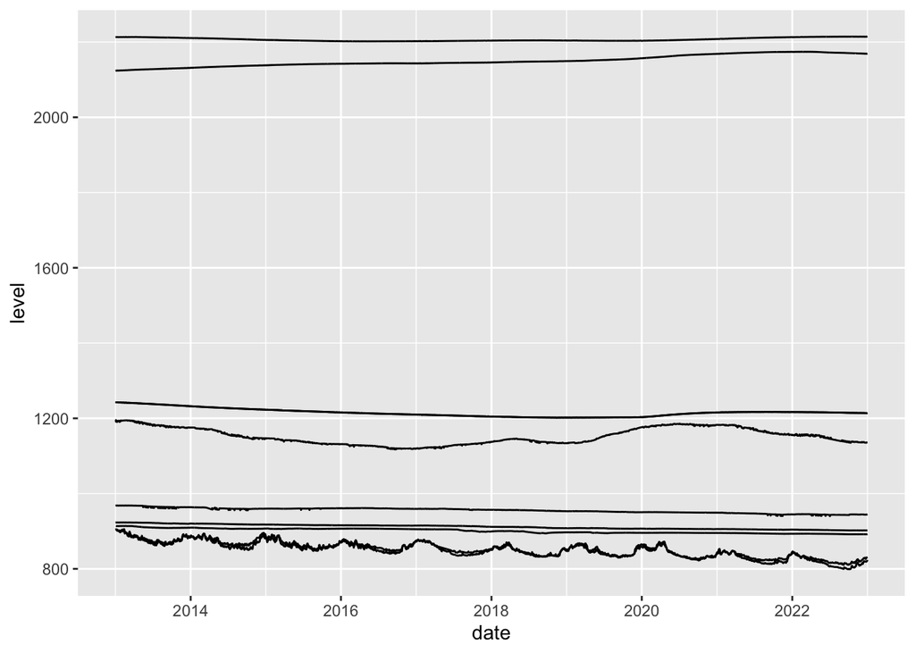

```r
# 1st dataset: create new objects from original dataframes for plotting

# new san bernardino county dataframe for plotting (also combine 5 parts into one)
san_bernardino1_plot <- san_bernardino1 |>                                      # call original dataframe
                        rename("level_max" = "x230641_62611_00001",
                               "date" = datetime,
                               "site" = site_no) |>                             # rename columns for easier reading
                        select(date, site, level_max)                           # select relevant columns
san_bernardino2_plot <- san_bernardino2 |>                                      # call original dataframe
                        rename("level_max" = "x230641_62611_00001",
                               "date" = datetime,
                               "site" = site_no) |>                             # rename columns for easier reading
                        select(date, site, level_max)                           # select relevant columns
san_bernardino3_plot <- san_bernardino3 |>                                      # call original dataframe
                        rename("level_max" = "x230641_62611_00001",
                               "date" = datetime,
                               "site" = site_no) |>                             # rename columns for easier reading
                        select(date, site, level_max)                           # select relevant columns
san_bernardino4_plot <- san_bernardino4 |>                                      # call original dataframe
                        rename("level_max" = "x230641_62611_00001",
                               "date" = datetime,
                               "site" = site_no) |>                             # rename columns for easier reading
                        select(date, site, level_max)                           # select relevant columns
san_bernardino5_plot <- san_bernardino5 |>                                      # call original dataframe
                        rename("level_max" = "x230641_62611_00001",
                               "date" = datetime,
                               "site" = site_no) |>                             # rename columns for easier reading
                        select(date, site, level_max)                           # select relevant columns
# combine parts & continue organization
sb_levels <- rbind(san_bernardino1_plot,
                   san_bernardino2_plot,
                   san_bernardino3_plot,
                   san_bernardino4_plot,
                   san_bernardino5_plot) |>                                     # use rbind to combine into one dataframe
                   mutate("level" = level_max) |>                               # simplify "level" column name
                   select(date, site, level) |>                                 # select relevant columns
                   na.omit() |>                                                 # remove rows (dates) with no data
                   arrange(desc(date)) |>                                       # reorder by date
                   slice(32317:386043)                                          # choose dates 2013-01-01 to 2023-01-01 (for exaclty 10 years of data)

# supplementary dataframe to help find best representative monitoring sites by ones with the most data
sb_sum <- sb_levels |>                                                          # call original dataframe
          mutate(occurence = 1) |>                                              # add column "occurence" to be able to sum # of datapoints for each site
          group_by(site) |>                                                     # group by site
          summarize_at("occurence", sum) |>                                     # sum occurences by site
          ungroup() |>                                                          # ungroup!
          arrange(-occurence) |>                                                # order from high to low
          slice(1:10)                                                           # choose top 10 sites with most data

# list of top 10 monitoring sites (aka very basic data dictionary)
#340521117212001 = site1
#340046117020803 = site2
#340503117104101 = site3
#340615117170902 = site4
#340136117033903 = site5
#340716117230601 = site6
#340521117212005 = site7
#340927117242201 = site8
#340927117242202 = site9
#340508117163303 = site10

# create new data frames for each monitoring site
site1 <- sb_levels |>                                                           # call original dataframe
         filter(site %in% "340521117212001")                                    # select relevant site
site2 <- sb_levels |>                                                           # same as above
         filter(site %in% "340046117020803")
site3 <- sb_levels |>
         filter(site %in% "340503117104101")
site4 <- sb_levels |>
         filter(site %in% "340615117170902")
site5 <- sb_levels |>
         filter(site %in% "340136117033903")
site6 <- sb_levels |>
         filter(site %in% "340716117230601")
site7 <- sb_levels |>
         filter(site %in% "340521117212005")
site8 <- sb_levels |>
         filter(site %in% "340927117242201")
site9 <- sb_levels |>
         filter(site %in% "340927117242202")
site10 <- sb_levels |>
          filter(site %in% "340508117163303")

# exploratory plot of monitoring wells in San Bernardino county to see which sites I should use as representative for the whole county
ggplot() +                                                                      # plot all on same graph to see trends
  geom_line(data = site1, aes(x = date, y = level)) +                           # identify dataframe & x/y axes
  geom_line(data = site2, aes(x = date, y = level)) +                           # same as above
  geom_line(data = site3, aes(x = date, y = level)) +
  geom_line(data = site4, aes(x = date, y = level)) +
  geom_line(data = site5, aes(x = date, y = level)) +
  geom_line(data = site6, aes(x = date, y = level)) +
  geom_line(data = site7, aes(x = date, y = level)) +
  geom_line(data = site8, aes(x = date, y = level)) +
  geom_line(data = site9, aes(x = date, y = level)) +
  geom_line(data = site10, aes(x = date, y = level))
```

```r
# based on exploratory plot, will use sites 1, 4, 7 & 10
# create dataframe with only relevant sites for plotting
well_sites <- rbind(site1, site4, site7, site10) |>                             # call 4 sites w most data & combine
              pivot_wider(names_from = "site", values_from = "level") |>        # pivot wider so eac site is its own column
              rename("site1" = "340521117212001",
                     "site4" = "340615117170902",
                     "site7" = "340521117212005",
                     "site10" = "340508117163303") |>                           # rename sites w/ better names
              pivot_longer(2:5, names_to = "site", values_to = "level")         # pivot back to original form for plotting

# 2nd dataset: create new object from original dataframe for plotting

# new reported dry wells dataframe with just wells from San Bernardino county
sb_wells <- dry_wells |>                                                        # call original dataframe
            filter(county %in% "San Bernardino") |>                             # only select wells in San Bernardino
            arrange(report_date) |>                                             # reorder by report date
            select(report_date, latitude, longitude, city, id) |>               # select relevant columns
            na.omit() |>                                                        # remove rows w no data
            mutate(occurence = c(0, 10, 20,
                                 0, 10,
                                 0, 10, 20, 30, 40,
                                 0, 10, 20, 30, 40,
                                 0, 10,
                                 0))                                            # add occurence column for plotting
```

#### Step 4: Plot 1

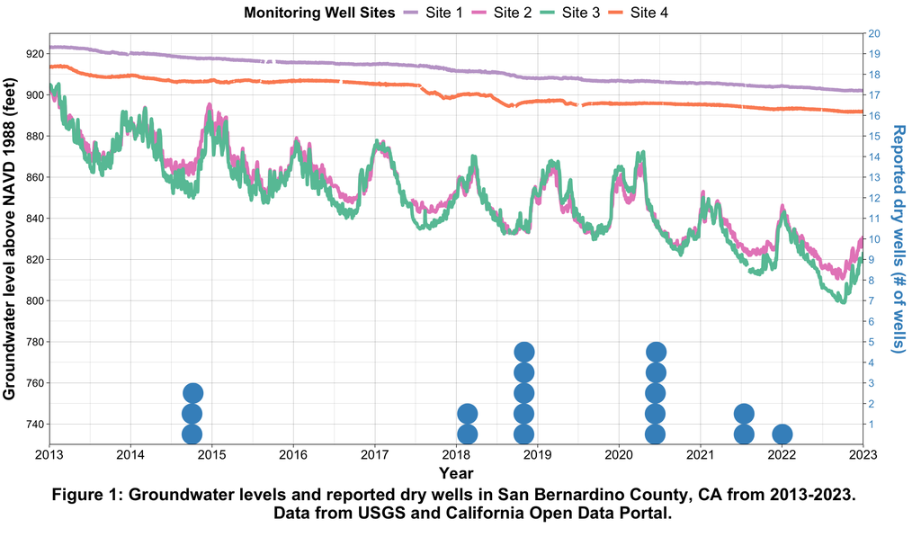

```r
# create coefficient for transforming second axis
coeff <- 735

# figure 1: 4 representative monitoring wells' water levels between 2013-2023 for San Bernardino county + number of wells that have gone dry in the same time period and county
ggplot() +

# 1st geom: line graphs showing water levels for 4 monitoring wells (in feet above NAVD 1988)
  geom_line(data = well_sites,                                                  # identify dataframe
            aes(x = date, y = level,                                            # identify x/y axes
                group = site, color = site),                                    # identify how to group/color lines
            size = 1.5) +                                                       # line size

# 2nd geom: point plot showing number of wells that have gone dry
  geom_point(data = sb_wells,                                                   # identify dataframe
           aes(x = report_date, y = occurence + coeff),                         # x/y axes & transformation for 2nd axis
           size = 8.5, color = "#4292c6") +                                     # size/color

# labels
  labs(x = "Year",
       y = "Groundwater level above NAVD 1988 (feet)",                          # x/y axis labels
       caption = "Figure 1: Groundwater levels and reported dry wells in San Bernardino County, CA from 2013-2023.
       Data from USGS and California Open Data Portal.") +                      # caption

# axis formatting
  scale_x_date(date_breaks = "1 year",                                          # group dates by year
               date_labels = "%Y",                                              # identify how dates shown on axis
               expand = c(0, 0)) +                                              # no gaps between data/axis
  scale_y_continuous(expand = c(0, 0),                                          # no gaps between data/axis
                     limits = c(730, 930),                                      # y axis limits
                     breaks = scales::pretty_breaks(n = 10),                    # axis label breaks
                     sec.axis = sec_axis(trans = ~.*0.1-73,                     # add 2nd axis & using transformation
                                name = "Reported dry wells (# of wells)",       # label axis
                                breaks = 1:20)) +                               # axis labels -> start w/ 1 instead of 0

# coloring for 1st geom
  scale_color_manual(values = c(site1 = "#c2a5cf",
                                site4 = "#66c2a5",
                                site7 = "#fc8d62",
                                site10 = "#e78ac3"),                             # assign colors to the sites
                     labels = c(site1 = "Site 1",
                                site7 = "Site 4",
                                site4 = "Site 3",
                                site10 = "Site 2"),                             # assign legend names to the column names
                     name = "Monitoring Well Sites") +                          # name legend

# theme stuff: aesthetics
  ggplot2::theme_linedraw() +                                                   # plain background w/ major gridlines
  theme(axis.text = element_text(color = "#000000", size = 12),                 # axis numbers color/size
        axis.text.y.right = element_text(color = "#4292c6", size = 10),         # 2nd y axis color to match data color
        axis.text.y.left = element_text(color = "#000000", size = 10),          # 1st y axis color/size
        axis.title.x = element_text(color = "#000000", size = 15,               # x axis label color/size
                                    face = "bold",                              # bold text
                                    margin = margin(t = 5, "mm")),              # margin around axis
        axis.title.y.left = element_text(color = "#000000", size = 15,          # y axis label color/size
                                         face = "bold",                         # bold text
                                         margin = margin(r = 8, "mm")),         # margin around axis
        axis.title.y.right = element_text(color = "#4292c6", size = 15,         # 2nd y axis label color/size (matches data color)
                                          face = "bold",                        # bold text
                                          margin = margin(l = 10, "mm")),       # adjust margin between axis title & text
        plot.caption = element_text(hjust = 0.5, color = "#000000",             # align caption, color
                                    size = 16, face = "bold"),                  # caption size/bold
        legend.text = element_text(size = 14),                                  # legend text size
        legend.title = element_text(color = "#000000", size = 14,
                                    face = "bold"),                             # legend title size/color/bold
        legend.position = "top",                                                # legend position
        legend.margin = margin(0, 0, 0, 0),                                     # no margin around legend
        plot.margin = margin(1, 5, 5, 1, "mm"))                                 # margins around graph (so x axis text isn't cut off)
```

#### Step 5: Organize data for Plot 2

```r
# 3rd dataset: create new object from original dataframe for mapping

# new county boundaries data frame for joining with dry wells occurences
counties_plot <- counties |>                                                    # call dataframe
                 st_transform(5070) |>                                          # identify projection
                 select(countyfp, "county" = name)                              # select relevant columns

# 2nd dataset: create new objects from original dataframes for plotting

# new reported dry wells dataframe for plotting
wells_plot <- dry_wells |>                                                      # call original dataframe
              mutate(occurence = 1)                                             # add column "occurence" to be able to sum how many wells were reported dry by county (see county_map)

# supplementary dataframe to get number of dry wells per county for 2nd plot
county_map <- wells_plot |>                                                     # call original dataframe
              select(county, occurence) |>                                      # select relevant columns
              group_by(county) |>                                               # group by county
              summarize_at(1, sum, na.rm = TRUE) |>                             # sum occurences by county
              ungroup() |>                                                      # ungroup!
              right_join(counties_plot, by = "county") |>                       # join spatial info to wells info
              mutate_at(vars(2), ~replace(., is.na(.), 0)) |>                   # replace NA values w/ 0 so all counties will have a value
              st_as_sf(crs = 5070)                                              # make dataframe an sf
```

#### Step 6: Plot 2

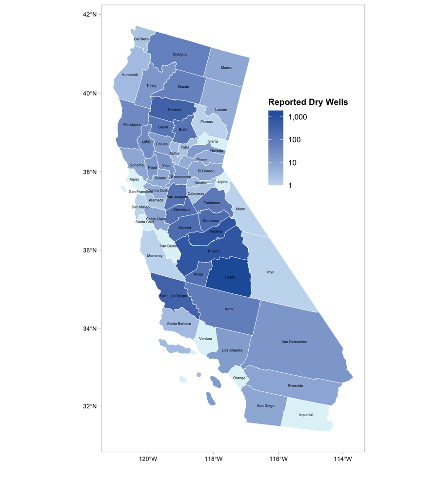

```r
# figure 2: geospatial map of the number of wells that have gone dry by county in CA
ggplot(data = county_map) +                                                     # identify dataframe

# 1st geom: geospatial map showing # of reported wells per county
  geom_sf(mapping = aes(fill = occurence),                                      # fill counties by # of reported dry wells
          col = "white", size = 10) +                                           # county boundary line color/size

# labels
  labs(x = " ", y = " ",                                                        # no x/y labels for clean look
  caption = "Figure 2: Reported dry wells by county in California between 2013-2023.
       Data from California Open Data Portal.") +                               # caption

# 2nd geom: label county names
  geom_sf_text(aes(label = county),                                             # label county names
               size = 1.5, color = "#000000") +                                 # color/size

# color in counties
  scale_fill_gradient(name = "Reported Dry Wells",                              # name legend
                      trans = "log2",                                           # transform legend to be logrithmic to fit data
                      breaks = c(0, 1, 10, 100, 1000),                          # identify breaks on legend
                      labels = scales::comma,                                   # add commas
                               c(0, 1, 10, 100, 1000),                          # identify break labels
                      low = "#c6dbef", high = "#225ea8",                        # identify color scale
                      na.value = "#e0f3f8") +                                   # identify color for 0 wells reported

# theme stuff: aesthetics
  theme_light() +                                                               # plain background w/ box around map
  theme(legend.title = element_text(size = 10, face = "bold"),                  # legend text size/bold
        legend.position = c(.95, 0.8),                                          # put legend inside plot
        legend.justification = c("right", "top"),                               # legend location
        legend.box.just = "right",                                              # legend justification
        legend.margin = margin(4, 4, 4, 4),                                     # margin around legend
        legend.key = element_rect(colour = "#000000"),                          # format color scale
        plot.caption = element_text(hjust = 0.5,                                # caption justification
                                    color = "#000000", size = 12,               # caption color
                                    face = "bold",                              # bold
                                    margin = margin(t = 0, "mm")),              # margin around caption
        panel.grid = element_blank(),                                           # no gridlines
        axis.text = element_text(color = "#000000", size = 7))                  # axis text color & size
```

**Plot 2 conclusion:**  
The number of reported dry wells over the past decade have been overwhelmingly from agricultural areas, like the central valley. This is because agriculture relies heavily on wells for irrigation & water is getting scarcer.